# Exploratory Data Analysis and Stock Price and Stock Price Trend Prediction

### Analyze the returns of all the stocks

```python
closing_df = pdr.get_data_yahoo(['AAPL','GOOG','MSFT','AMZN'],start,end)['Adj Close']
```

```
[*********************100%***********************]  4 of 4 downloaded
```

```python
closing_df.head()
```

| Date | AAPL | AMZN | GOOG | MSFT |
| --- | --- | --- | --- | --- |
| 2017-01-03 | 112.620964 | 753.669983 | 786.140015 | 60.171543 |
| 2017-01-04 | 112.494911 | 757.179993 | 786.900024 | 59.902313 |
| 2017-01-05 | 113.066986 | 780.450012 | 794.020020 | 59.902313 |
| 2017-01-06 | 114.327484 | 795.989990 | 806.150024 | 60.421535 |
| 2017-01-09 | 115.374664 | 796.919983 | 806.650024 | 60.229233 |

#### Creating a Dataframe tech_rets for Daily returns of every company stock

```python
tech_rets = closing_df.pct_change()
```

```python
tech_rets.head()
```

| Date | AAPL | AMZN | GOOG | MSFT |
| --- | --- | --- | --- | --- |
| 2017-01-03 | NaN | NaN | NaN | NaN |
| 2017-01-04 | -0.001119 | 0.004657 | 0.000967 | -0.004474 |
| 2017-01-05 | 0.005085 | 0.030732 | 0.009048 | 0.000000 |
| 2017-01-06 | 0.011148 | 0.019912 | 0.015277 | 0.008668 |
| 2017-01-09 | 0.009159 | 0.001168 | 0.000620 | -0.003183 |

#### Now we can compare the daily percentage return of two stocks to check how correlated.

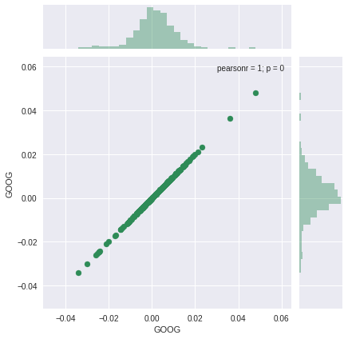

```python
# Comparing Google to itself should show a perfectly linear relationship
sns.jointplot('GOOG','GOOG',tech_rets,kind='scatter',color='seagreen')
```

#### So now we can see that if two stocks are perfectly (and positivley) correlated with each other a linear relationship bewteen its daily return values should occur.

#### Comparing GOOGLE and MICROSOFT Stocks

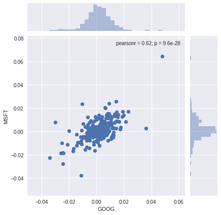

```python
sns.jointplot('GOOG','MSFT',tech_rets,kind='scatter')
```

#### Pearsonr value officially known as the Pearson product-moment correlation coefficient

- How correlated the daily percentage returns are.

```python
from IPython.display import SVG
SVG(url='http://upload.wikimedia.org/wikipedia/commons/d/d4/Correlation_examples2.svg')
```

[figure not shown]

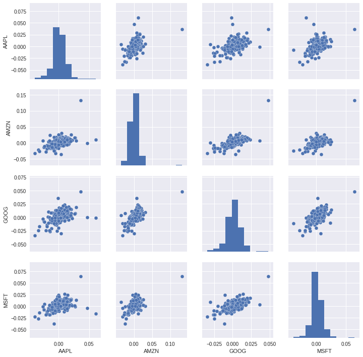

```python
sns.pairplot(tech_rets.dropna())
```

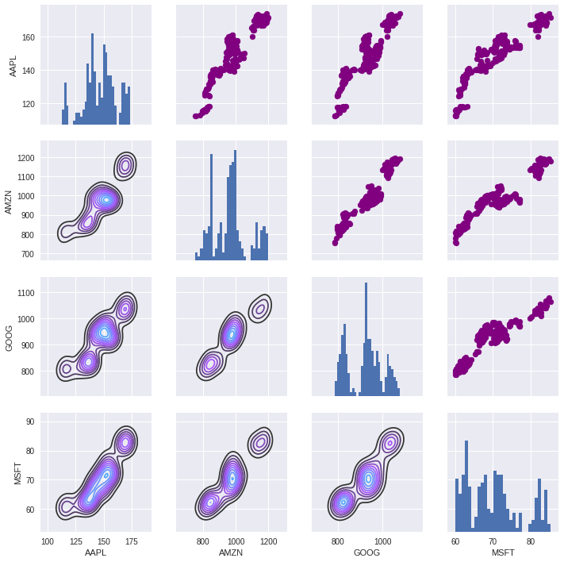

```python
returns_fig = sns.PairGrid(closing_df)

returns_fig.map_upper(plt.scatter,color='purple')
returns_fig.map_lower(sns.kdeplot,cmap='cool_d')
returns_fig.map_diag(plt.hist,bins=30)
```

# Stock Price Predictions:

### Benchmark Model:

Lets build the test data that we will feed into Benchmark Model as well as the LSTM

```python
test_start = "2017-01-01"
test_end = "2017-01-31"
test = pdr.get_data_yahoo("GOOG",test_start,test_end)
```

```
[*********************100%***********************]  1 of 1 downloaded
```

```python
test.head()
```

| Date | Open | High | Low | Close | Adj Close | Volume |
| --- | --- | --- | --- | --- | --- | --- |
| 2017-01-03 | 778.809998 | 789.630005 | 775.799988 | 786.140015 | 786.140015 | 1657300 |
| 2017-01-04 | 788.359985 | 791.340027 | 783.159973 | 786.900024 | 786.900024 | 1073000 |
| 2017-01-05 | 786.080017 | 794.479980 | 785.020020 | 794.020020 | 794.020020 | 1335200 |
| 2017-01-06 | 795.260010 | 807.900024 | 792.203979 | 806.150024 | 806.150024 | 1640200 |
| 2017-01-09 | 806.400024 | 809.966003 | 802.830017 | 806.650024 | 806.650024 | 1272400 |

```python
real_stock_price = test.iloc[:, 0:1].values
```

### We will try to predict the trend of Open prices

```python
real_stock_price
```

```
array([[778.809998],
       [788.359985],
       [786.080017],
       [795.26001 ],
       [806.400024],
       [807.859985],
       [805.      ],
       [807.140015],
       [807.47998 ],
       [807.080017],
       [805.809998],
       [805.119995],
       [806.909973],
       [807.25    ],
       [822.299988],
       [829.619995],
       [837.809998],
       [834.710022],
       [814.659973]])
```

### Lets build a function that Calculates trend

1) If the Trend is Upwards it will be +1  
2) If the Trend is Downward it will be -1

```python
def cal_target(df):
    list_y =[]
    temp = df
    for i in range(len(temp)-1):
        if temp[i+1] > temp[i]:
            y = 1
        else:
            y = -1

        list_y.append(int(y))
    return list_y
```

```python
real_stock_price_trend = cal_target(real_stock_price)
```

### This is trend of real stock prices

```python
real_stock_price_trend
```

```
[1, -1, 1, 1, 1, -1, 1, 1, -1, -1, -1, 1, 1, 1, 1, 1, -1, -1]
```

### Lets run benchmark, Random choice of 50-50%

```python
benchmark_trend_prediction = list(np.random.choice([-1,1], 18))
benchmark_trend_prediction
```

```
[-1, -1, -1, -1, 1, -1, 1, 1, 1, -1, -1, 1, 1, -1, 1, -1, -1, -1]
```

```python
combine_df = pd.DataFrame({"Real":real_stock_price_trend,"Predicted Benchmark":benchmark_trend_prediction})

combine_df
```

|  | Predicted Benchmark | Real |
| --- | --- | --- |
| 0 | -1 | 1 |
| 1 | -1 | -1 |
| 2 | -1 | 1 |
| 3 | -1 | 1 |
| 4 | 1 | 1 |
| 5 | -1 | -1 |
| 6 | 1 | 1 |
| 7 | 1 | 1 |
| 8 | 1 | -1 |
| 9 | -1 | -1 |
| 10 | -1 | -1 |
| 11 | 1 | 1 |
| 12 | 1 | 1 |
| 13 | -1 | 1 |
| 14 | 1 | 1 |
| 15 | -1 | 1 |
| 16 | -1 | -1 |
| 17 | -1 | -1 |

### Lets calculate the accuracy of the benchmark model

```python
from sklearn.metrics import accuracy_score
score = accuracy_score(real_stock_price_trend, benchmark_trend_prediction)
print(score)
```

```
0.6666666666666666
```

# Now lets start with prediction using LSTM

### There are two ways for stock price prediction:

**1) Financial Concepts such as Technical Indicators**  
**2) Deep Learning with Time series data**

## Techincal Indicators:

### 1)Trend indicators

These technical indicators measure the direction and strength of a trend by comparing prices to an established baseline.

**a) Moving Averages:** Used to identify trends and reversals, as well as to set up support and resistance levels.  
**b) Parabolic Stop and Reverse (Parabolic SAR):** Used to find potential reversals in the market price direction.  
**c) Moving Average Convergence Divergence (MACD):** Used to reveal changes in the strength, direction, momentum, and duration of a trend in a stock’s price.

### 2) Momentum indicators

These technical indicators may identify the speed of price movement by comparing the current closing price to previous closes.

**a) Stochastic Oscillator:** Used to predict price turning points by comparing the closing price to its price range.  
**b)Commodity Channel Index (CCI):** An oscillator that helps identify price reversals, price extremes, and trend strength.  
**c)Relative Strength Index (RSI):** Measures recent trading strength, velocity of change in the trend, and magnitude of the move.

### 3) Volatility Indicators

These technical indicators measure the rate of price movement, regardless of direction.

**a) Bollinger bands:** Measures the “highness” or “lowness” of price, relative to previous trades.  
**b) Average True Range:** Shows the degree of price volatility.  
**c) Standard Deviation:** Used to measure expected risk and to determine the significance of certain price movements.

### 4) Volume Indicators

These technical indicators measure the strength of a trend based on volume of shares traded.

**a) Chaikin Oscillator:** Monitors the flow of money in and out of the market, which can help determine tops and bottoms.  
**b) On-Balance Volume (OBV):** Attempts to measure level of accumulation or distribution, by comparing volume to price.  
**c) Volume Rate of Change:** Highlights increases in volume. These normally happen mostly at market tops, bottoms, or breakouts.

### For these Project I will use Deep Learning for Stock Price Predictions:

#### ◈ Recurrent Neural Networks (RNN) are best for handling sequential data.

#### ◈ RNNs share parameters across different positions/ index of time/ time steps of the sequence, which makes it possible to generalize well to examples of different sequence length.

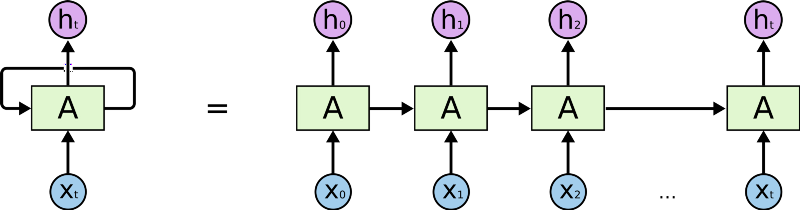

```python
from IPython.core.display import Image
Image(filename='files/rnn.png')
```

#### The main drawbackof Recurrent Neural Network is Vanishing Gradient Problem

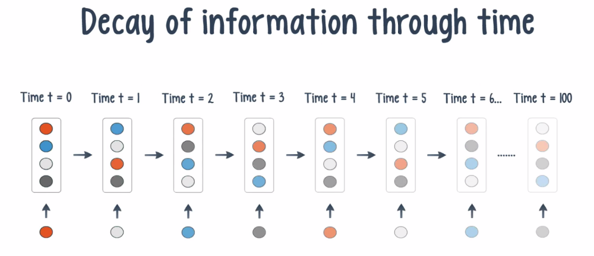

```python
Image(filename='files/vgp.png')
```

### This problem was solved by Sepp Hochreiter and Jürgen Schmidhuber in 1997

#### Long short-term memory (LSTM) units (or blocks) are a building unit for layers of a recurrent neural network (RNN).

A RNN composed of LSTM units is often called an LSTM network. A common LSTM unit is composed of a cell, an input gate, an output gate and a forget gate. The cell is responsible for "remembering" values over arbitrary time intervals; hence the word "memory" in LSTM. Each of the three gates can be thought of as a "conventional" artificial neuron, as in a multi-layer (or feedforward) neural network: that is, they compute an activation (using an activation function) of a weighted sum. Intuitively, they can be thought as regulators of the flow of values that goes through the connections of the LSTM; hence the denotation "gate". There are connections between these gates and the cell.

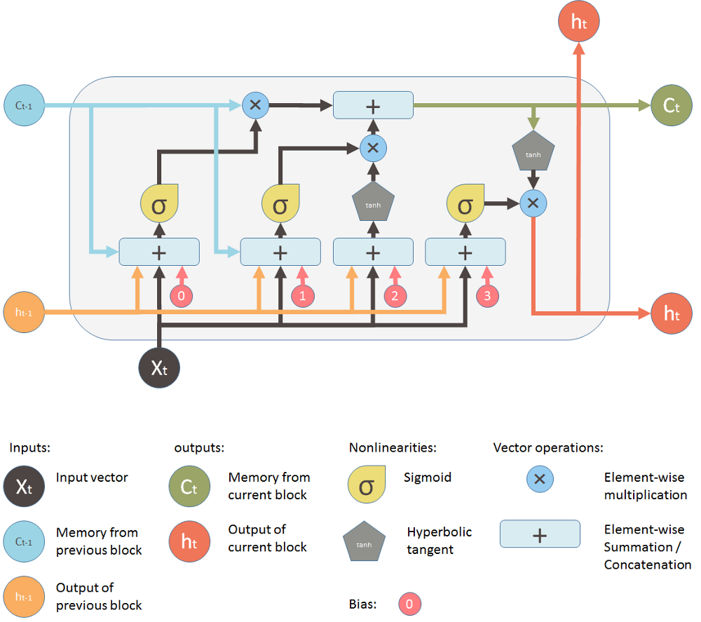

```python
Image(filename='files/lstm_final.png')
```

```python
training_start = "2012-01-01"
training_end = "2017-01-01"
train = pdr.get_data_yahoo("GOOG",training_start,training_end)
```

```
[*********************100%***********************]  1 of 1 downloaded
```

```python
train.shape
```

```
(1258, 6)
```

```python
training_set = train.iloc[:, 0:1].values
training_set
```

```
array([[324.360352],
       [330.366272],
       [328.925659],
       ...,
       [793.700012],
       [783.330017],
       [782.75    ]])
```

```python
test_start = "2017-01-01"
test_end = "2017-02-01"
test = pdr.get_data_yahoo("GOOG",test_start,test_end)
```

```
[*********************100%***********************]  1 of 1 downloaded
```

```python
test.head(20)
```

| Date | Open | High | Low | Close | Adj Close | Volume |
| --- | --- | --- | --- | --- | --- | --- |
| 2017-01-03 | 778.809998 | 789.630005 | 775.799988 | 786.140015 | 786.140015 | 1657300 |
| 2017-01-04 | 788.359985 | 791.340027 | 783.159973 | 786.900024 | 786.900024 | 1073000 |
| 2017-01-05 | 786.080017 | 794.479980 | 785.020020 | 794.020020 | 794.020020 | 1335200 |
| 2017-01-06 | 795.260010 | 807.900024 | 792.203979 | 806.150024 | 806.150024 | 1640200 |
| 2017-01-09 | 806.400024 | 809.966003 | 802.830017 | 806.650024 | 806.650024 | 1272400 |
| 2017-01-10 | 807.859985 | 809.130005 | 803.510010 | 804.789978 | 804.789978 | 1176800 |
| 2017-01-11 | 805.000000 | 808.150024 | 801.369995 | 807.909973 | 807.909973 | 1065900 |
| 2017-01-12 | 807.140015 | 807.390015 | 799.169983 | 806.359985 | 806.359985 | 1353100 |
| 2017-01-13 | 807.479980 | 811.223999 | 806.690002 | 807.880005 | 807.880005 | 1099200 |
| 2017-01-17 | 807.080017 | 807.140015 | 800.369995 | 804.609985 | 804.609985 | 1355800 |
| 2017-01-18 | 805.809998 | 806.205017 | 800.989990 | 806.070007 | 806.070007 | 1294400 |
| 2017-01-19 | 805.119995 | 809.479980 | 801.799988 | 802.174988 | 802.174988 | 919300 |
| 2017-01-20 | 806.909973 | 806.909973 | 801.690002 | 805.020020 | 805.020020 | 1670000 |
| 2017-01-23 | 807.250000 | 820.869995 | 803.739990 | 819.309998 | 819.309998 | 1963600 |
| 2017-01-24 | 822.299988 | 825.900024 | 817.820984 | 823.869995 | 823.869995 | 1474000 |
| 2017-01-25 | 829.619995 | 835.770020 | 825.059998 | 835.669983 | 835.669983 | 1494500 |
| 2017-01-26 | 837.809998 | 838.000000 | 827.010010 | 832.150024 | 832.150024 | 2973900 |
| 2017-01-27 | 834.710022 | 841.950012 | 820.440002 | 823.309998 | 823.309998 | 2965800 |
| 2017-01-30 | 814.659973 | 815.840027 | 799.799988 | 802.320007 | 802.320007 | 3246600 |
| 2017-01-31 | 796.859985 | 801.250000 | 790.520020 | 796.789978 | 796.789978 | 2160600 |

```python
test.shape
```

```
(20, 6)
```

```python
real_stock_price = test.iloc[:, 0:1].values
```

```python
real_stock_price.shape
```

```
(20, 1)
```

#### Feature Scaling

```python
# Feature Scaling
from sklearn.preprocessing import MinMaxScaler
sc = MinMaxScaler(feature_range = (0, 1))
training_set_scaled = sc.fit_transform(training_set)
```

```python
training_set_scaled
```

```
array([[0.08545249],
       [0.09660926],
       [0.09393314],
       ...,
       [0.95731171],
       [0.9380481 ],
       [0.93697064]])
```

#### Creating a data structure with 60 timesteps and 1 output

```python
X_train = []
y_train = []
for i in range(60, 1258):
    X_train.append(training_set_scaled[i-60:i, 0])
    y_train.append(training_set_scaled[i, 0])
X_train, y_train = np.array(X_train), np.array(y_train)
```

```python
print(X_train)
```

```
[[0.08545249 0.09660926 0.09393314 ... 0.07812537 0.07999865 0.08461274]
 [0.09660926 0.09393314 0.09118315 ... 0.07999865 0.08461274 0.08591389]
 [0.09393314 0.09118315 0.07950958 ... 0.08461274 0.08591389 0.08435434]
 ...
 [0.92118079 0.92448743 0.93058039 ... 0.95482243 0.95211037 0.95170163]
 [0.92448743 0.93058039 0.93000453 ... 0.95211037 0.95170163 0.95731171]
 [0.93058039 0.93000453 0.93123052 ... 0.95170163 0.95731171 0.9380481 ]]
```

```python
print(y_train)
```

```
[0.08591389 0.08435434 0.07422185 ... 0.95731171 0.9380481  0.93697064]
```

#### Reshaping

```python
X_train = np.reshape(X_train, (X_train.shape[0], X_train.shape[1], 1))
```

### Part 2 - Building the LSTM

#### Importing the Keras libraries

```python
from keras.models import Sequential
from keras.layers import Dense
from keras.layers import LSTM
from keras.layers import Dropout
```

#### Initialising the LSTM

```python
regressor = Sequential()
```

#### Adding the first LSTM layer and some Dropout regularisation

```python
regressor.add(LSTM(units = 50, return_sequences = True, input_shape = (X_train.shape[1], 1)))
regressor.add(Dropout(0.2))
```

#### Adding a second LSTM layer and some Dropout regularisation

```python
regressor.add(LSTM(units = 50, return_sequences = True))
regressor.add(Dropout(0.2))
```

#### Adding a third LSTM layer and some Dropout regularisation

```python
regressor.add(LSTM(units = 50, return_sequences = True))
regressor.add(Dropout(0.2))
```

#### Adding a fourth LSTM layer and some Dropout regularisation

```python
regressor.add(LSTM(units = 50))
regressor.add(Dropout(0.2))
```

#### Adding the output layer

```python
regressor.add(Dense(units = 1))
```

#### Compiling the LSTM

```python
regressor.compile(optimizer = 'adam', loss = 'mean_squared_error')
```

#### Fitting the LSTM to the Training set

```python
history = regressor.fit(X_train, y_train, epochs = 100, batch_size = 32)
```

```python
# Getting the predicted stock price of 2017
dataset_total = pd.concat((train['Open'], test['Open']), axis = 0)
inputs = dataset_total[len(dataset_total) - len(test) - 60:].values
inputs = inputs.reshape(-1,1)
inputs = sc.transform(inputs)
X_test = []
for i in range(60, 80):
    X_test.append(inputs[i-60:i, 0])
X_test = np.array(X_test)
X_test = np.reshape(X_test, (X_test.shape[0], X_test.shape[1], 1))
predicted_stock_price = regressor.predict(X_test)
predicted_stock_price = sc.inverse_transform(predicted_stock_price)
```

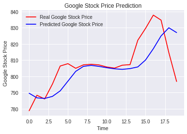

```python
plt.plot(real_stock_price, color = 'red', label = 'Real Google Stock Price')
plt.plot(predicted_stock_price, color = 'blue', label = 'Predicted Google Stock Price')
plt.title('Google Stock Price Prediction')
plt.xlabel('Time')
plt.ylabel('Google Stock Price')
plt.legend()
plt.show()
```

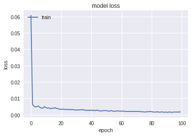

```python
# summarize history for loss
plt.plot(history.history['loss'])
plt.title('model loss')
plt.ylabel('loss')
plt.xlabel('epoch')
plt.legend(['train'], loc='upper left')
plt.show()
```

### The LSTM network predict the prices, lets convert the regression into classification problem and calculate the trend and then compare the predicted trend and acutual trend

```python
real_stock_price_trend = cal_target(real_stock_price)
predicted_stock_price_trend =cal_target(predicted_stock_price)
```

```python
real_stock_price_trend
```

```
[1, -1, 1, 1, 1, -1, 1, 1, -1, -1, -1, 1, 1, 1, 1, 1, -1, -1, -1]
```

```python
predicted_stock_price_trend
```

```
[-1, -1, 1, 1, 1, 1, 1, 1, -1, -1, -1, -1, 1, 1, 1, 1, 1, 1, -1]
```

### Stock Price Trend Prediction:

```python
combine_df = pd.DataFrame({"Real Stock Price":real_stock_price_trend,"Predicted Stock Price Trend":predicted_stock_price_trend})
combine_df
```

|  | Predicted Stock Price Trend | Real Stock Price |
| --- | --- | --- |
| 0 | -1 | 1 |
| 1 | -1 | -1 |
| 2 | 1 | 1 |
| 3 | 1 | 1 |
| 4 | 1 | 1 |
| 5 | 1 | -1 |
| 6 | 1 | 1 |
| 7 | 1 | 1 |
| 8 | -1 | -1 |
| 9 | -1 | -1 |
| 10 | -1 | -1 |
| 11 | -1 | 1 |
| 12 | 1 | 1 |
| 13 | 1 | 1 |
| 14 | 1 | 1 |
| 15 | 1 | 1 |
| 16 | 1 | -1 |
| 17 | 1 | -1 |
| 18 | -1 | -1 |

```python
from sklearn.metrics import accuracy_score
score = accuracy_score(real_stock_price_trend, predicted_stock_price_trend)
print(score)
```

```
0.7368421052631579
```

```python
from sklearn.metrics import classification_report
print(classification_report(real_stock_price_trend, predicted_stock_price_trend))
```

```
              precision    recall  f1-score   support

          -1       0.71      0.62      0.67         8
           1       0.75      0.82      0.78        11

   micro avg       0.74      0.74      0.74        19
   macro avg       0.73      0.72      0.72        19
weighted avg       0.73      0.74      0.73        19
```

### Accuracy Score = 0.7368421052631579

### F-1 Score = 0.73

```python
from sklearn.metrics import confusion_matrix
confusion_matrix(real_stock_price_trend, predicted_stock_price_trend)
```

```
array([[5, 3],
       [2, 9]])
```